# Protein and DNA sequence analysis

Jamie

February 6, 2019

```
## [1] "neuraminidase, partial [Influenza A virus (A/goose/Hong Kong/739.2/2002(H5N1))]"
## [2] "neuraminidase [Influenza A virus (A/Hong Kong/213-DkPass/2003(H5N1))]"
## [3] "neuraminidase [Influenza A virus (A/duck/Zhejiang/bj/2002(H5N1))]"
## [4] "neuraminidase [Influenza A virus (A/duck/Yokohama/aq10/2003(H5N1))]"
## [5] "neuraminidase [Influenza A virus (A/duck/Zhejiang/52/2000(H5N1))]"
## [6] "neuraminidase [Influenza A virus (A/swine/Fujian/2001(H5N1))] >gi|645170224|gb|AIB06160.1| neuraminidase [Influenza A virus (A/swine/Shandong/SD2/2013(H1N1))] >gi|1040461697|gb|ANN44988.1| neuraminidase [Influenza A virus (A/swine/Shandong/SD1/2014(H5N1))]"
## [7] "neuraminidase, partial [Influenza A virus (A/Hong Kong/213/2003(H5N1))]"
```

### Unknown protein sequence matched with **‘neuraminidase’** protein of the Influenza A virus via the NCBI database

Neuraminidase is an enzyme protein present on the surface of the Influenza virus. This protein is often used as an antigen in vaccines to prevent the spread of influenza. Presence of the protein in the blood sample suggests influenza infection.

Learn more about Influenza [here](https://en.wikipedia.org/wiki/Influenza)

# Protein sequence analysis

### A phylogenetic relationship of the 8 most closely related neuraminidase **protein** sequences

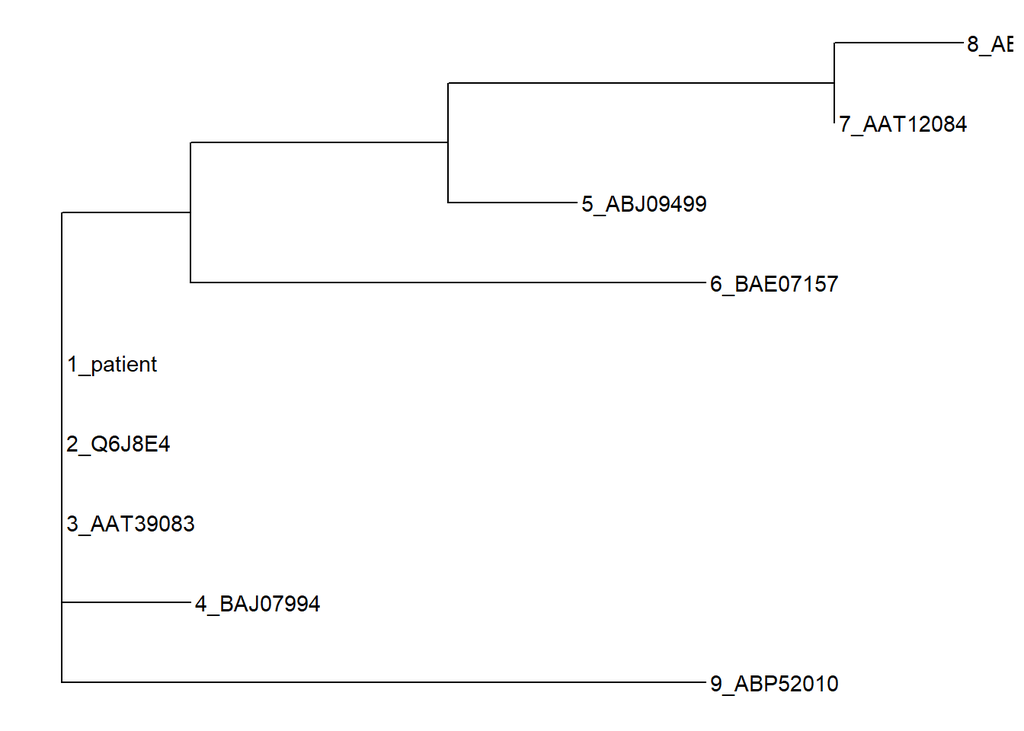

# DNA sequence analysis

```
##
## Number of sequences: 12
## Number of sites: 476
##
## No gap in alignment.
##
## Number of segregating sites (including gaps): 16
## Number of sites with at least one substitution: 16
## Number of sites with 1, 2, 3 or 4 observed bases:
##   1   2   3   4
## 460  16   0   0
```

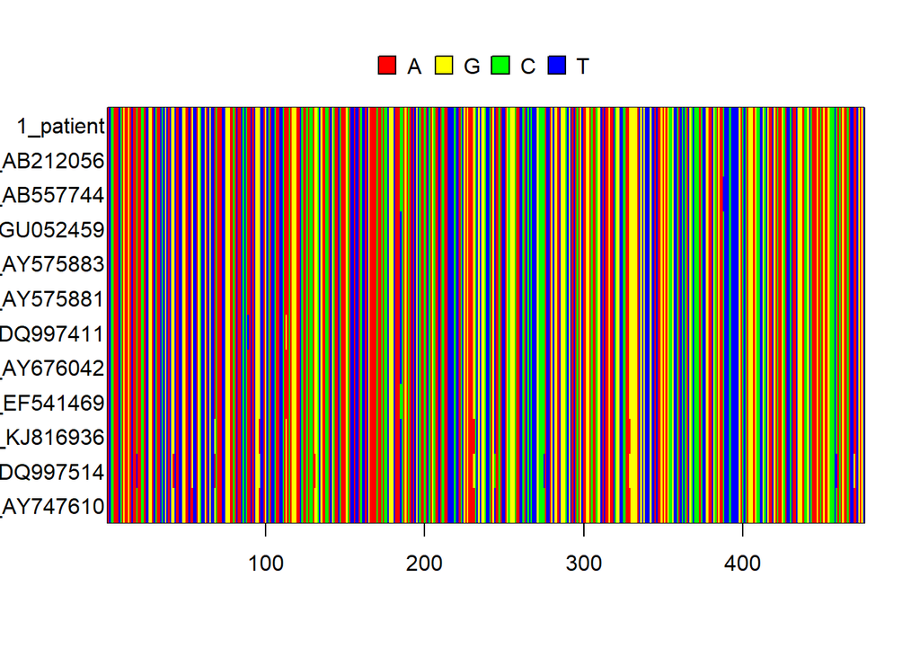

### A phylogenetic relationship of the 12 most closely related neuraminidase **DNA** sequences and a heatmap comparing sequence similarity

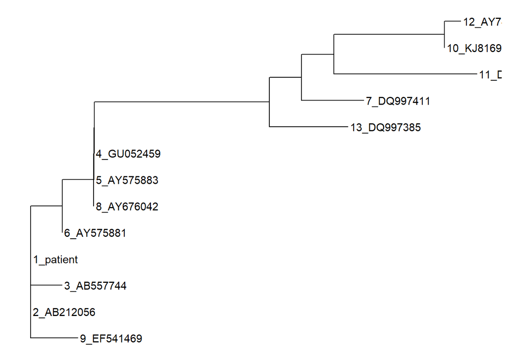

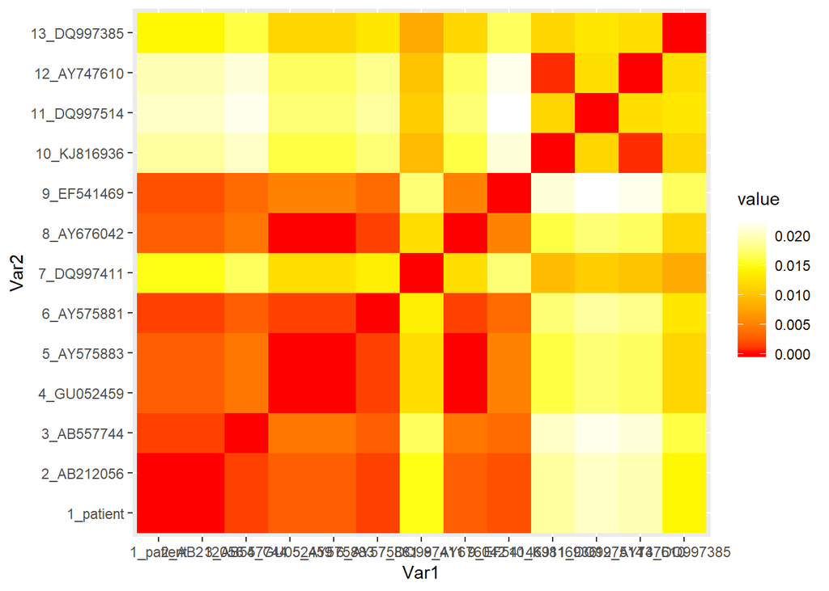

# Appendix I - alternative models

### F84 model- comparison of the phylogenetic tree output and heatmap graph

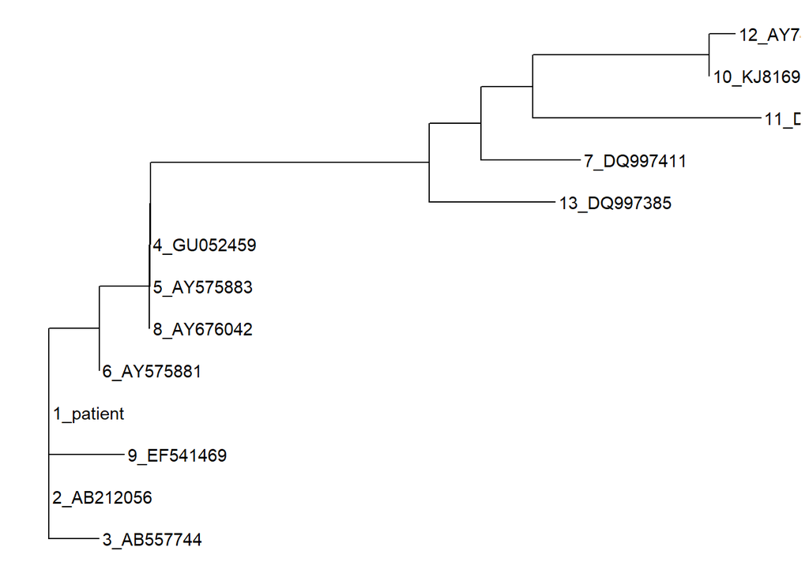

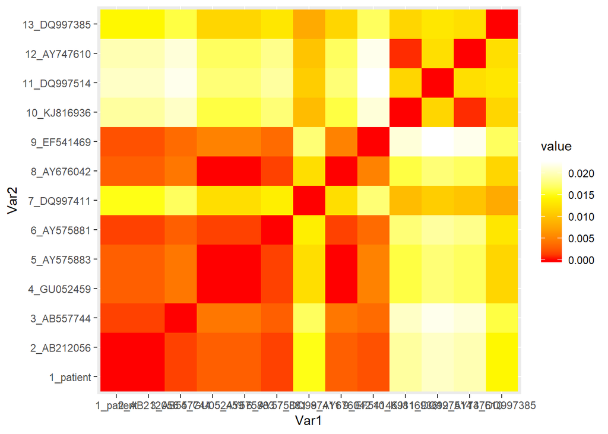

- Model F84 provides a phylogenetic tree and heatmap identical to the K80 model

### TN93 model - comparison of phylogenetic tree and heatmap graph

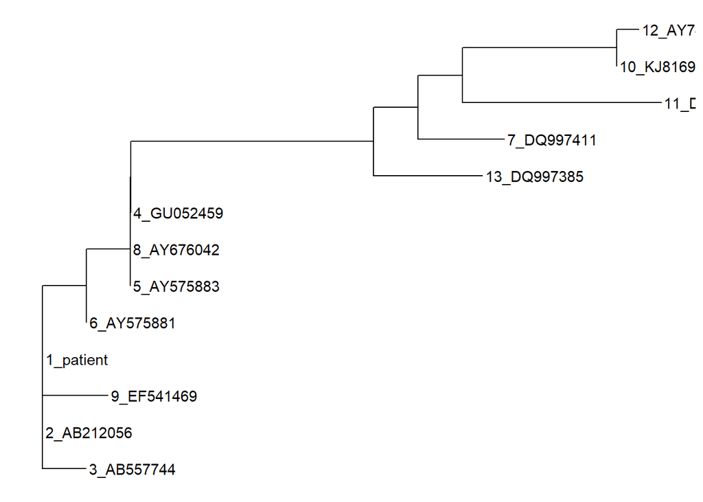

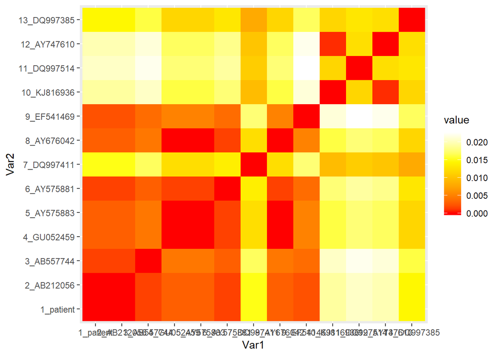

- The TN93 model also creates a phylogenetic tree and heatmap identical to the K80 model

## Comparison of the neighbor-joining and minimum evolution trees for the F84 model

### Neighbor-joining

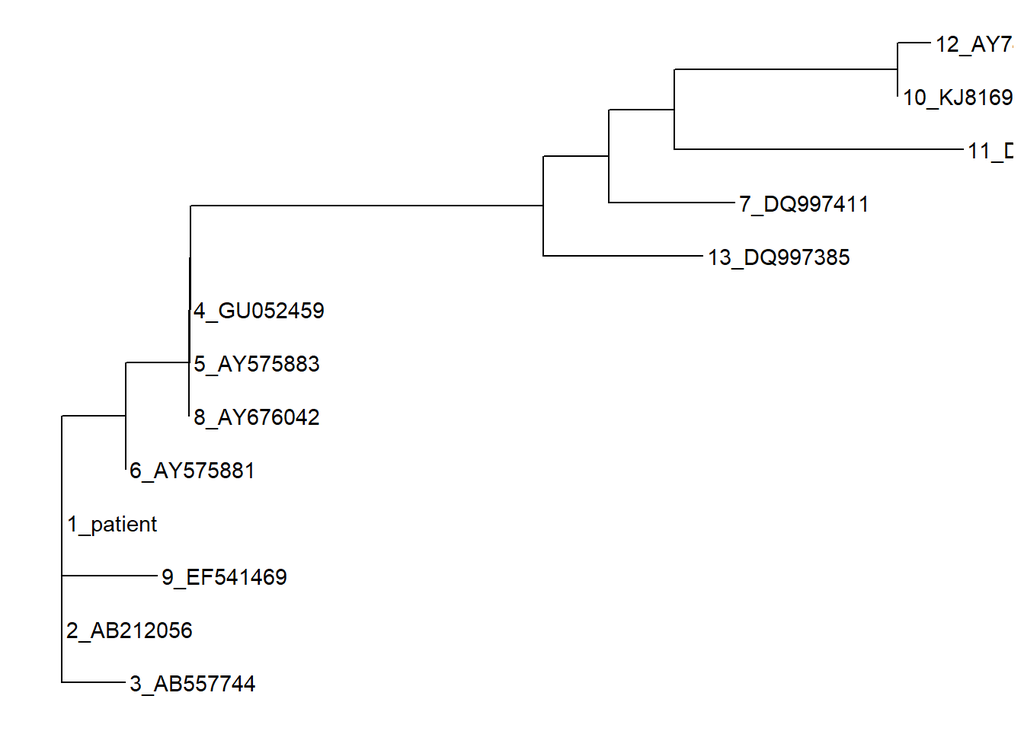

### Minimum evolution

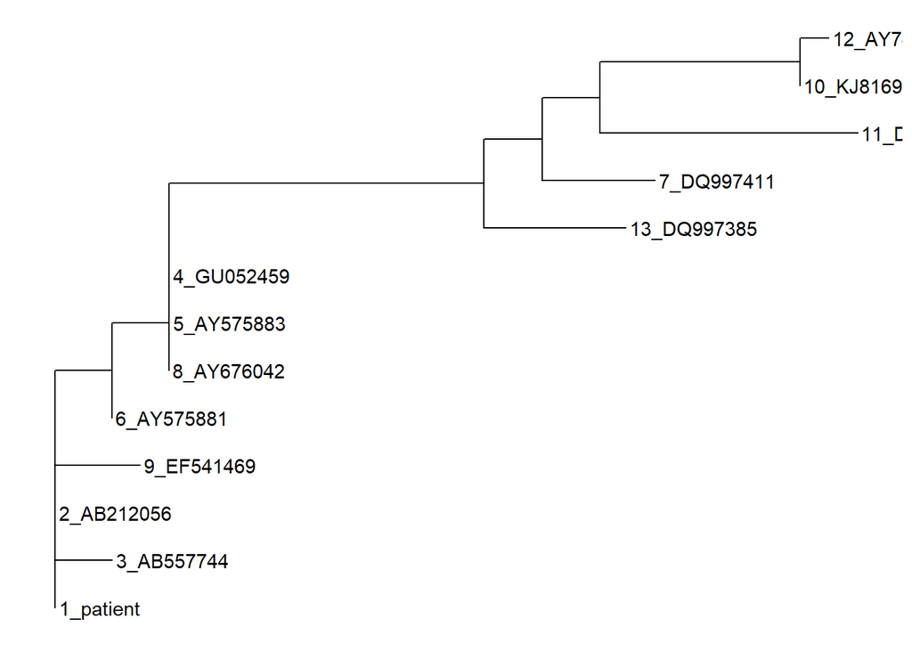

- The neighbor-joining and minimum evolution trees create similar, but not identical phylogenetic trees. It can be seen that some closely-related sequences sequences (including that of the patient) are in different positions near the base of he tree. However, as any node of a phylogenetic tree can be rotated and the lengths of the branches are the same, the phylogenetic relationships are the same.